# Лабораторная работа № 2

Предварительная настройка оборудования Cisco

Абд эль хай М.

Российский университет дружбы народов, Москва, Россия

024 февраля 2024

# Цель работы

## Цель работы

Получить основные навыки по начальному конфигурированию оборудования Cisco.

# Задание

## Настройку маршрутизатора

- задать имя в виде «город-территория-учётная_записьтип_оборудования-номер»;
- задать интерфейсу Fast Ethernet с номером 0 ip-адрес 192.168.1.254 и маску 255.255.255.0, затем поднять интерфейс;
- задать пароль для доступа к привилегированному режиму (сначала в открытом виде, затем — в зашифрованном);

## Настройку коммутатора

- задать имя в виде «город-территория-учётная_запись-тип_оборудования-номер»
- задать интерфейсу vlan 2 ip-адрес 192.168.2.1 и маску 255.255.255.0, затем поднять интерфейс;
- привязать интерфейс Fast Ethernet с номером 1 к vlan 2;
- задать в качестве адреса шлюза по умолчанию адрес 192.168.2.254;

# Выполнение лабораторной работы

## Схема

- В логическом рабочем пространстве Packet Tracer я разместил коммутатор, маршрутизатор и 2 конечных точки ПК, подключил один ПК к маршрутизатору, другой ПК к коммутатору.

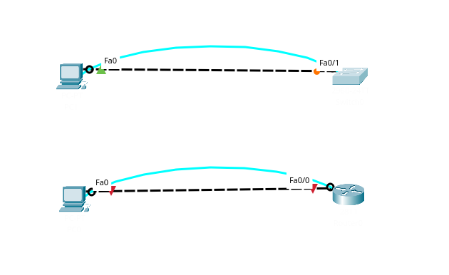

Схема подключения оборудования для проведения его предварительной настройки

# Конфигурация маршрутизатора

## Конфигурация маршрутизатора 1/6

Установка имени хоста Команда: имя хоста msk-obruchevsky-gw-1 Эта команда устанавливает имя хоста маршрутизатора «msk-obruchevsky-gw-1».

[figure not shown]

router

## Конфигурация маршрутизатора 2/6

Настройка интерфейса f0/0 Команды: - interface f0/0 - no shutdown - ip address 192.168.1.254 255.255.255.0 Эти команды включают интерфейс f0/0 и назначают этому интерфейсу IP-адрес 192.168.1.254 с маской подсети 255.255.255.0.

Эти команды устанавливают пароли для виртуального терминала (VTY) и линий консоли, включают секрет для привилегированного режима, шифруют пароли и создают пользователя «admin» с уровнем привилегий 1 и паролем «adminpassword».

## Конфигурация маршрутизатора 3/6

Эти команды задают имя домена, генерируют пару ключей RSA для шифрования и настраивают SSH в качестве транспортного входа для линий VTY.

[figure not shown]

ssh key router

## Конфигурация маршрутизатора 4/6

[figure not shown]

## Конфигурация маршрутизатора 5/6

я подключился к роутеру через SSH

[figure not shown]

shh router

## Конфигурация маршрутизатора 6/6

Затем я настроил vty 1 на использование telnet и подключился от PC0 к маршрутизатору с помощью telnet.

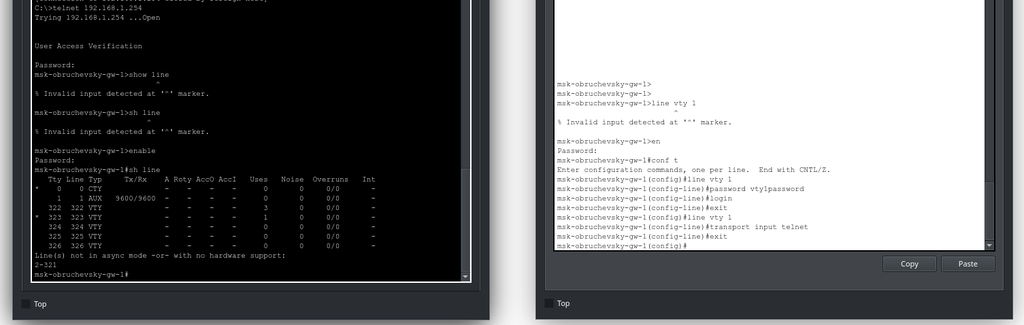

telnet router

# Конфигурация коммутатора

## Конфигурация коммутатора 1/7

### Настройка интерфейса VLAN

Команды в интерфейсе vlan2 и интерфейсе f0/1 настраивают интерфейс VLAN и режим порта коммутатора для доступа.

### Настройка IP-адреса и шлюза по умолчанию

Команды ip адрес 192.168.2.1 255.255.255.0 и ip default-gateway 192.168.2.254 назначают IP-адреса интерфейсам и устанавливают шлюз по умолчанию для коммутатора.

## Конфигурация коммутатора 2/7

### Настройка линий доступа и шифрования

Команды, относящиеся к строке vty 0 4, строке консоли 0, включению секрета, шифрованию паролей службы, имени пользователя, имени домена IP, генерации криптографического ключа rsa и входному транспортному протоколу ssh, настраивают линии доступа, включают шифрование паролей, создают пользователя. с определенными привилегиями, настройкой доменного имени, созданием пары ключей RSA для шифрования и указанием SSH в качестве входного транспортного сигнала для безопасного доступа.

## Конфигурация коммутатора 3/7

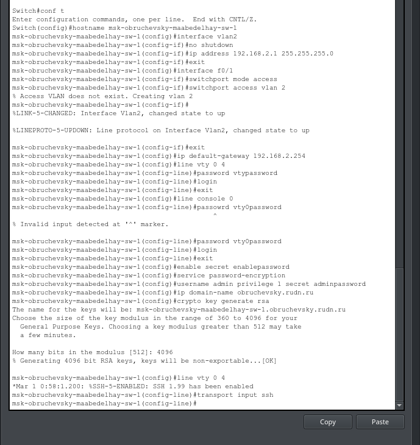

switch conf

## Конфигурация коммутатора 4/7

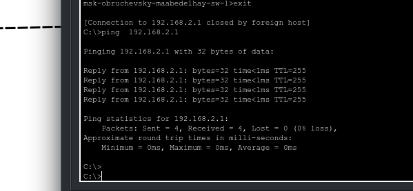

ping switch

## Конфигурация коммутатора 5/7

[figure not shown]

ssh switch

## Конфигурация коммутатора 6/7

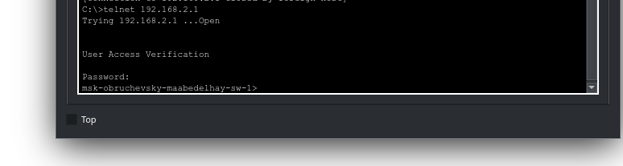

telnet ssh

## Конфигурация коммутатора 7/7

[figure not shown]

ping ssh

# Выводы

## Выводы

Я научился настраивать коммутатор и маршрутизатор и получать удаленный доступ через SSH/Telnet.